# Machine learning workflow

This workflow is based on the article by Gabriel Pierobon (2018. “A comprehensive Machine Learning workflow with multiple modelling using caret and caretEnsemble in R”)

Gabriel Pierobon’s main reference in this article is the book along with the dataset published by Brett Lanz (2015. Machine Learning with R, Packt Publishing) Pierobon’s intention in his article is to execute “a full supervised machine learning workflow” using caret and caretEnsemble packages.

## Modeling political stability

I am applying his workflow on “modeling concrete strength” to the political stability and absence of violence/terrorism Modeling the political stability estimate (PV)

### The six phases of a machine learning workflow:

According to Pierobon, it is a good practive to split the workflow into the following six (6) phases:

1. Setting
2. Exploratory Data Analysis
3. Feature of the target variable (political stability estimate in this case)
4. Data Preparation
5. Modelling
6. Conclusion

Note: in practice, one may end up jumping from one phase to another, which is quite normal in any data analysis.

#### 1. Setting

1.1 - What are we trying to predict?

We are trying to predict:

- the political stability score of countries on the scale of -3 to 2.5,
- the classification of countries in two categories:
- stable (with a score from 0 to 2.5) or
- unstable (with a score from -3 to 0),
- the classification of countries in four categories:
- highly stable (with a score from 1 to 2.5),
- moderately stable (with a score from 0 to .99),
- moderately unstable (with a score from -.99 to 0), and
- highly unstable (with a score from -3 to -1)

1.2 - What type of problem is it? - Supervised learning, - Classification and Regression

We are dealing in this case with a multivariate supervised machine learning problem in which we have to predict a numeric outcome (thus we will use a mutliple regression technique) and a binary and multi-class outcome (thus we will use classification techniques).

1.4 - Load the required packages and import the data

After importing the data, we can see its dimension and structure

```r
library(readr)
library(dplyr)
```

```r
library(ggplot2)
library(PerformanceAnalytics)
library(ggthemes)
library(corrplot)
library(car)
library(psych)
library(caret)
library(caretEnsemble)
library(doParallel)
library(Hmisc)
library(VIF)
# we are using the dataframe WGIdevRegimeType2.csv with imputation for inequality and poverty headcount

WGIdevRegimeType <- read_csv("WGIdevRegimeType.csv")
WGIdevRegimeType <- tbl_df(WGIdevRegimeType)
WGIdevRegimeType <- WGIdevRegimeType[, -1] #removing the first column
WGIdevRegimeType$date <- as.numeric(as.character(WGIdevRegimeType$date))
dim(WGIdevRegimeType)
```

```
## [1] 2345   45
```

```r
summary(WGIdevRegimeType)
```

```
##    country            M49Code             iso2c
##  Length:2345        Length:2345        Length:2345
##  Class :character   Class :character   Class :character
##  Mode  :character   Mode  :character   Mode  :character
##
##
##
##     iso3c                date        stability        stabilityDummy
##  Length:2345        Min.   :1996   Min.   :-2.84465   Min.   :0.0000
##  Class :character   1st Qu.:2004   1st Qu.:-0.75097   1st Qu.:0.0000
##  Mode  :character   Median :2009   Median :-0.07755   Median :0.0000
##                     Mean   :2008   Mean   :-0.12948   Mean   :0.4682
##                     3rd Qu.:2013   3rd Qu.: 0.59742   3rd Qu.:1.0000
##                     Max.   :2017   Max.   : 1.76010   Max.   :1.0000
##  stabilityCategory  corruptionControl  governmentEffectiveness
##  Length:2345        Min.   :-1.82574   Min.   :-2.06299
##  Class :character   1st Qu.:-0.79827   1st Qu.:-0.69787
##  Mode  :character   Median :-0.33963   Median :-0.15032
##                     Mean   :-0.02452   Mean   : 0.03776
##                     3rd Qu.: 0.62590   3rd Qu.: 0.70732
##                     Max.   : 2.46999   Max.   : 2.43697
##  regulatoryQuality    ruleOfLaw        voiceAndAccountability
##  Min.   :-2.29754   Min.   :-2.13000   Min.   :-2.22605
##  1st Qu.:-0.62490   1st Qu.:-0.81923   1st Qu.:-0.82700
##  Median :-0.10120   Median :-0.30043   Median :-0.11553
##  Mean   : 0.06278   Mean   :-0.04135   Mean   :-0.05308
##  3rd Qu.: 0.77220   3rd Qu.: 0.69902   3rd Qu.: 0.74624
##  Max.   : 2.26054   Max.   : 2.10027   Max.   : 1.80099
##   GNIperCapita      devCategory        GDPannualGrowthRate
##  Min.   :   204.9   Length:2345        Min.   :-36.700
##  1st Qu.:  1284.2   Class :character   1st Qu.:  2.079
##  Median :  4582.6   Mode  :character   Median :  4.057
##  Mean   : 13186.6                      Mean   :  4.093
##  3rd Qu.: 15296.0                      3rd Qu.:  6.184
##  Max.   :102456.7                      Max.   : 64.068
##       HDI              GINI      povertyHeadCount  polityScore
##  Min.   :0.2530   Min.   :16.2   Min.   : 0.00    Min.   :-10.000
##  1st Qu.:0.5460   1st Qu.:35.3   1st Qu.: 0.70    1st Qu.: -1.000
##  Median :0.7030   Median :40.2   Median : 4.60    Median :  7.000
##  Mean   :0.6785   Mean   :40.1   Mean   :13.38    Mean   :  4.309
```

[output cut: 36 more lines]

```
##  Max.   :7.000   Max.   :14.000   Max.   :7.000
##    inverse_pr      inverse_cl     inverse_mean   politicalChangeFH
##  Min.   :1.000   Min.   :1.000   Min.   :1.000   Length:2345
##  1st Qu.:3.000   1st Qu.:3.000   1st Qu.:3.000   Class :character
##  Median :5.000   Median :5.000   Median :5.000   Mode  :character
##  Mean   :4.581   Mean   :4.647   Mean   :4.614
##  3rd Qu.:7.000   3rd Qu.:6.000   3rd Qu.:6.500
##  Max.   :7.000   Max.   :7.000   Max.   :7.000
##     region           subregion
##  Length:2345        Length:2345
##  Class :character   Class :character
##  Mode  :character   Mode  :character
##
##
##
```

#### 2. Exploratory Data Analysis (EDA)

2.1 Viewing the data structure using glimpse in dplyr

```r
glimpse(WGIdevRegimeType)
```

```
## Observations: 2,345
## Variables: 45
## $ country                 <chr> "Angola", "Angola", "Angola", "Angola"...
## $ M49Code                 <chr> "024", "024", "024", "024", "024", "02...
## $ iso2c                   <chr> "AO", "AO", "AO", "AO", "AO", "AO", "A...
## $ iso3c                   <chr> "AGO", "AGO", "AGO", "AGO", "AGO", "AG...
## $ date                    <dbl> 2000, 2002, 2003, 2004, 2005, 2006, 20...
## $ stability               <dbl> -2.0355825, -1.5770464, -1.0065378, -1...
## $ stabilityDummy          <int> 0, 0, 0, 0, 0, 0, 0, 0, 0, 0, 0, 0, 0,...
## $ stabilityCategory       <chr> "Highly Unstable", "Highly Unstable", ...
## $ corruptionControl       <dbl> -1.5226851, -1.1836292, -1.3206655, -1...
## $ governmentEffectiveness <dbl> -1.4623097, -1.2388567, -1.1565313, -1...
## $ regulatoryQuality       <dbl> -1.7993306, -1.4631602, -1.2121437, -1...
## $ ruleOfLaw               <dbl> -1.6633072, -1.6173294, -1.5214102, -1...
## $ voiceAndAccountability  <dbl> -1.458064675, -1.238779068, -1.2726153...
```

[output cut: 32 more lines]

```r
names(WGIdevRegimeType)
```

```
##  [1] "country"                 "M49Code"
##  [3] "iso2c"                   "iso3c"
##  [5] "date"                    "stability"
##  [7] "stabilityDummy"          "stabilityCategory"
##  [9] "corruptionControl"       "governmentEffectiveness"
## [11] "regulatoryQuality"       "ruleOfLaw"
## [13] "voiceAndAccountability"  "GNIperCapita"
## [15] "devCategory"             "GDPannualGrowthRate"
## [17] "HDI"                     "GINI"
## [19] "povertyHeadCount"        "polityScore"
## [21] "polityCategory"          "politicalChange"
## [23] "democ"                   "autoc"
## [25] "durable"                 "xrreg"
## [27] "xrcomp"                  "xropen"
## [29] "xconst"                  "parreg"
## [31] "parcomp"                 "exrec"
## [33] "exconst"                 "polcomp"
## [35] "pr"                      "cl"
## [37] "sum"                     "mean"
## [39] "status"                  "inverse_pr"
## [41] "inverse_cl"              "inverse_mean"
## [43] "politicalChangeFH"       "region"
## [45] "subregion"
```

**List of variables**

- Country Identification and Date:
- country
- M49Code
- iso2c
- region
- subregion
- date
- World Governance Indicators
- stability
- stabilityDummy
- stabilityCategory
- corruptionControl
- governmentEffectiveness
- regulatoryQuality
- ruleOfLaw
- voiceAndAccountability
- Development, Inequality, and Poverty Variables
- GNIperCapita
- devCategory
- GDPannualGrowthRate
- HDI
- GINI
- povertyHeadCount
- Polity IV Variables
- polityScore
- polityCategory
- politicalChange
- democ
- autoc
- durable
- xrreg
- xrcomp
- xropen
- xconst
- parreg
- parcomp
- exrec
- exconst
- polcomp
- FreedomHouse Variables
- pr
- cl
- mean
- status
- inverse_pr
- inverse_cl
- inverse_mean
- politicalChangeFH

variables to be included in the models:

myVariables <- c(region, subregion, date, stability, stabilityDummy, stabilityCategory, corruptionControl, governmentEffectiveness, regulatoryQuality, ruleOfLaw, voiceAndAccountability, GNIperCapita, devCategory, GDPannualGrowthRate, HDI, GINI, povertyHeadCount, polityScore, polityCategory,democ, autoc, durable, xrreg, xrcomp, xropen, xconst, parreg, parcomp, exrec, exconst, polcomp, statu, inverse_pr, inverse_cl, inverse_mean)

2.2 Viewing the summary and the distibution of the target variable using summary, boxplot and histogram with base r or ggplot

```r
summary(WGIdevRegimeType$stability)
```

```
##     Min.  1st Qu.   Median     Mean  3rd Qu.     Max.
## -2.84465 -0.75097 -0.07755 -0.12948  0.59742  1.76010
```

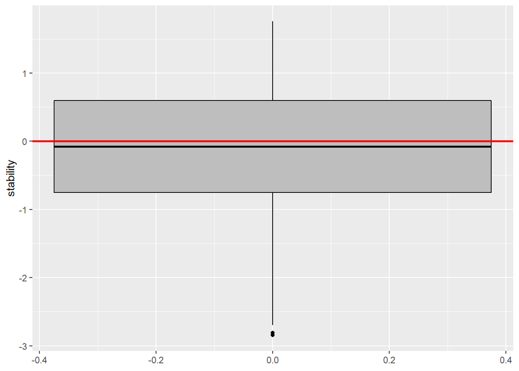

Fig. 1 - Summary Statistics of the Political Stability of the Whole World

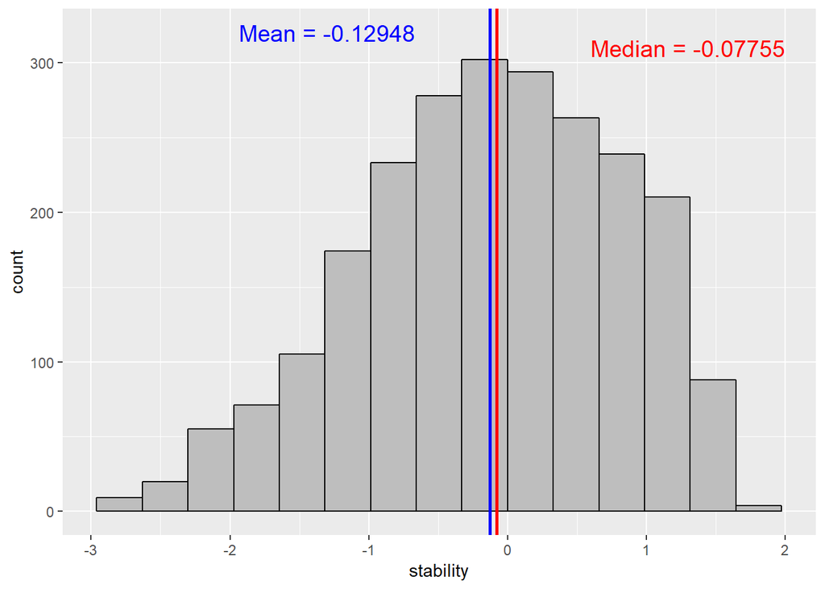

Fig. 2 - Histogram of the Political Stability of the Whole World

Figures 1 and 2 show that the distribution of the target variable is not perfectly normal, but we can procede regardless.

2.3 Trend of the Political Stability of the Whole World since the End of the Cold War

```
## # A tibble: 19 x 2
##     date AnnualAverage
##    <dbl>         <dbl>
##  1  1996       -0.0134
##  2  1998       -0.0127
##  3  2000       -0.0151
##  4  2002       -0.0150
##  5  2003       -0.113
##  6  2004       -0.139
##  7  2005       -0.115
##  8  2006       -0.116
##  9  2007       -0.130
## 10  2008       -0.148
## 11  2009       -0.169
## 12  2010       -0.209
## 13  2011       -0.173
## 14  2012       -0.151
## 15  2013       -0.144
## 16  2014       -0.118
## 17  2015       -0.123
## 18  2016       -0.175
## 19  2017       -0.335
```

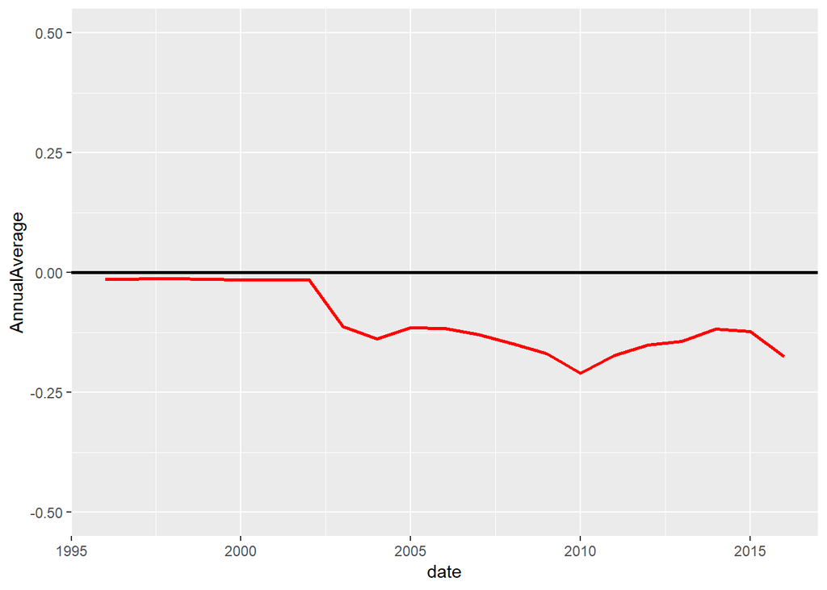

Fig. 3 - The Trend of Political Stability Score Around the World (1996-2016)

2.4 Comparing the summary statistics of stability around the world

```r
# Political Stability summary for each region

politicalStabilityByRegion <- summarise(group_by(WGIdevRegimeType, region),
          mean=mean(stability, na.rm = TRUE), sd=sd(stability, na.rm = TRUE))

politicalStabilityByRegion
```

```
## # A tibble: 5 x 3
##   region     mean    sd
##   <chr>     <dbl> <dbl>
## 1 Africa   -0.594 0.851
## 2 Americas -0.157 0.684
## 3 Asia     -0.368 0.918
## 4 Europe    0.613 0.647
## 5 Oceania   1.05  0.446
```

```r
# We compute the analysis of variance (ANOVA) to see if the differences of means are statistically significant
res.aov <- aov(stability ~ region, data = WGIdevRegimeType)

# Summary of the analysis of variance (ANOVA)
summary(res.aov)
```

```
##               Df Sum Sq Mean Sq F value Pr(>F)
## region         4  559.7  139.93   223.2 <2e-16 ***
## Residuals   2340 1466.7    0.63
## ---
## Signif. codes:  0 '***' 0.001 '**' 0.01 '*' 0.05 '.' 0.1 ' ' 1
```

```r
# As the ANOVA test is significant, we compute Tukey HSD (Tukey Honest Significant Differences) for performing multiple pairwise-comparison between the means of groups

TukeyHSD(res.aov)
```

```
##   Tukey multiple comparisons of means
##     95% family-wise confidence level
##
## Fit: aov(formula = stability ~ region, data = WGIdevRegimeType)
##
## $region
##                        diff        lwr        upr     p adj
## Americas-Africa   0.4371829  0.3021268  0.5722390 0.0000000
## Asia-Africa       0.2257894  0.1064347  0.3451442 0.0000026
## Europe-Africa     1.2068694  1.0850847  1.3286541 0.0000000
## Oceania-Africa    1.6462745  1.2904759  2.0020731 0.0000000
## Asia-Americas    -0.2113935 -0.3486789 -0.0741081 0.0002636
## Europe-Americas   0.7696865  0.6302834  0.9090896 0.0000000
## Oceania-Americas  1.2090916  0.8468839  1.5712993 0.0000000
## Europe-Asia       0.9810800  0.8568277  1.1053322 0.0000000
## Oceania-Asia      1.4204851  1.0638343  1.7771359 0.0000000
## Oceania-Europe    0.4394051  0.0819338  0.7968764 0.0071892
```

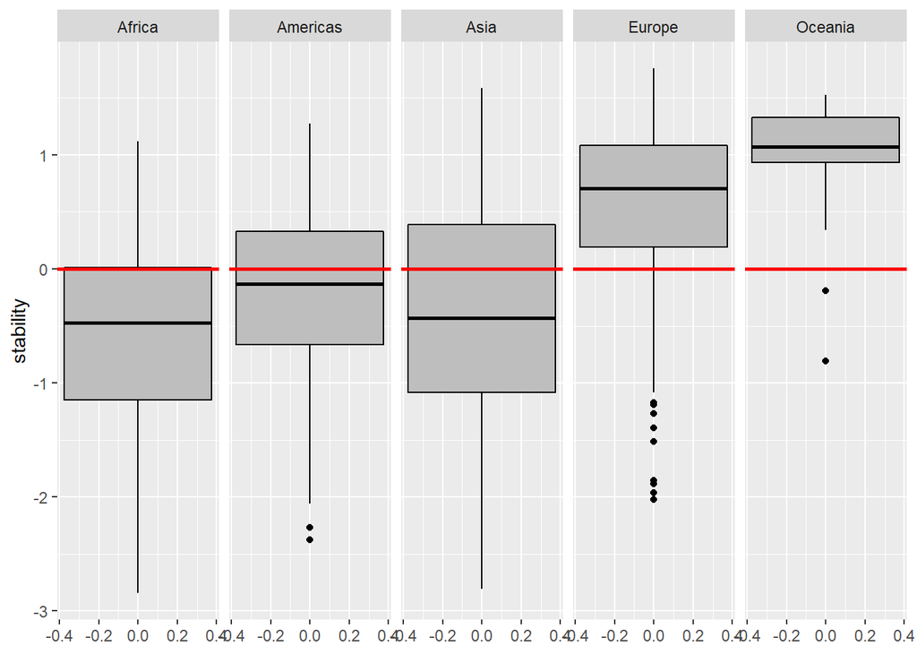

```r
ggplot(data = WGIdevRegimeType) +
  geom_boxplot(mapping = aes(y = stability), boundary = 0, fill = "grey", col = "black") +
  geom_hline(yintercept = 0, col = "red", size = 1) +
  facet_grid(~ region)
```

2.6 Viewing the correlation of political stability with the other variables

We can plot the correlation between all variables and also generate a correlation matrix.

As a result of this procedure, we can drop the unnecessary variables that do not have any correlation or weak correlation with stability.

Since we have too many variables, we can view the correlation by areas or groups of variables, such as:

1. correlation with the other world governance indicators
2. correlation with the economic development indicators
3. correlation with the main Polity IV variables (polityScore, democ, autoc, durable)
4. correlation with other Polity IV variables (from xreg to polcomp)
5. correlation with Freedom House variables

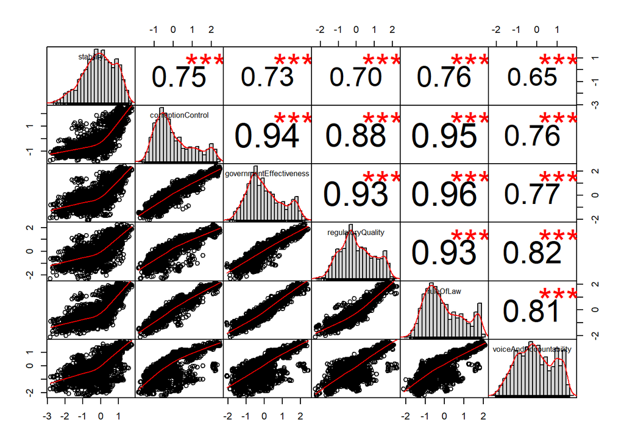

```r
# Correlation chart between Political Stability and the other World Governance Indicators (WGI)
WGI <- select(WGIdevRegimeType, stability, corruptionControl, governmentEffectiveness, regulatoryQuality, ruleOfLaw, voiceAndAccountability)
correlationWGI <- chart.Correlation(WGI)
```

```r
correlationWGI
```

```r
# Correlation matrix with significance levels
correlationWGI2 <- rcorr(as.matrix(WGI))
correlationWGI2
```

```
##                         stability corruptionControl
## stability                    1.00              0.75
## corruptionControl            0.75              1.00
## governmentEffectiveness      0.73              0.94
## regulatoryQuality            0.70              0.88
## ruleOfLaw                    0.76              0.95
## voiceAndAccountability       0.65              0.76
##                         governmentEffectiveness regulatoryQuality
## stability                                  0.73              0.70
## corruptionControl                          0.94              0.88
## governmentEffectiveness                    1.00              0.93
## regulatoryQuality                          0.93              1.00
## ruleOfLaw                                  0.96              0.93
## voiceAndAccountability                     0.77              0.82
##                         ruleOfLaw voiceAndAccountability
## stability                    0.76                   0.65
## corruptionControl            0.95                   0.76
## governmentEffectiveness      0.96                   0.77
## regulatoryQuality            0.93                   0.82
## ruleOfLaw                    1.00                   0.81
## voiceAndAccountability       0.81                   1.00
##
## n= 2345
##
##
## P
##                         stability corruptionControl
## stability                          0
## corruptionControl        0
## governmentEffectiveness  0         0
## regulatoryQuality        0         0
## ruleOfLaw                0         0
## voiceAndAccountability   0         0
##                         governmentEffectiveness regulatoryQuality
## stability                0                       0
## corruptionControl        0                       0
## governmentEffectiveness                          0
## regulatoryQuality        0
## ruleOfLaw                0                       0
## voiceAndAccountability   0                       0
##                         ruleOfLaw voiceAndAccountability
## stability                0         0
## corruptionControl        0         0
## governmentEffectiveness  0         0
## regulatoryQuality        0         0
## ruleOfLaw                          0
## voiceAndAccountability   0
```

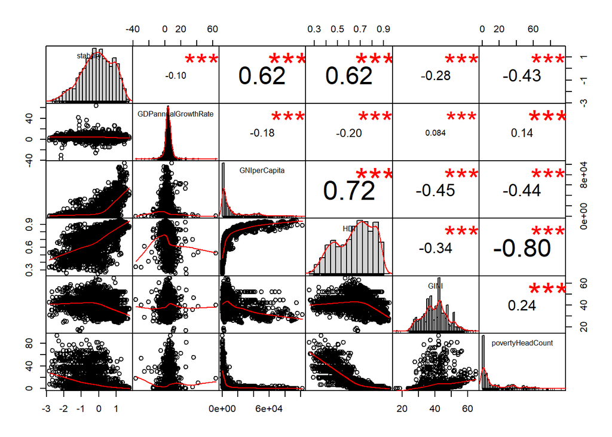

```r
# Correlation between Political Stability and economic and social indicators

devIndicators <- select(WGIdevRegimeType, stability, GDPannualGrowthRate, GNIperCapita, HDI, GINI, povertyHeadCount)
correlationDev <- chart.Correlation(devIndicators)
```

```r
correlationDev
```

```r
# Correlation matrix with significance levels
correlationDev2 <- rcorr(as.matrix(devIndicators))
correlationDev2
```

```
##                     stability GDPannualGrowthRate GNIperCapita   HDI  GINI
## stability                1.00               -0.10         0.62  0.62 -0.28
## GDPannualGrowthRate     -0.10                1.00        -0.18 -0.20  0.08
## GNIperCapita             0.62               -0.18         1.00  0.72 -0.45
## HDI                      0.62               -0.20         0.72  1.00 -0.34
## GINI                    -0.28                0.08        -0.45 -0.34  1.00
## povertyHeadCount        -0.43                0.14        -0.44 -0.80  0.24
##                     povertyHeadCount
## stability                      -0.43
## GDPannualGrowthRate             0.14
## GNIperCapita                   -0.44
## HDI                            -0.80
## GINI                            0.24
## povertyHeadCount                1.00
##
## n= 2345
##
##
## P
##                     stability GDPannualGrowthRate GNIperCapita HDI GINI
## stability                      0                   0            0   0
## GDPannualGrowthRate  0                             0            0   0
## GNIperCapita         0         0                                0   0
## HDI                  0         0                   0                0
## GINI                 0         0                   0            0
## povertyHeadCount     0         0                   0            0   0
##                     povertyHeadCount
## stability            0
## GDPannualGrowthRate  0
## GNIperCapita         0
## HDI                  0
## GINI                 0
## povertyHeadCount
```

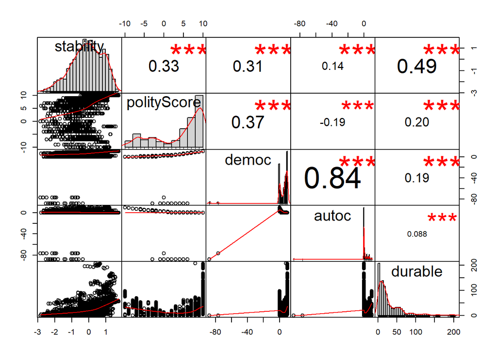

```r
# Correlation between Political Stability and the main Polity IV indicators

polityIvIndicators1 <- select(WGIdevRegimeType, stability, polityScore, democ, autoc, durable)
correlationPolityIv1 <- chart.Correlation(polityIvIndicators1)
```

```r
correlationPolityIv1
```

```r
# Correlation matrix with significance levels
correlationPolityIv1 <- rcorr(as.matrix(polityIvIndicators1))
correlationPolityIv1
```

```
##             stability polityScore democ autoc durable
## stability        1.00        0.33  0.31  0.14    0.49
## polityScore      0.33        1.00  0.37 -0.19    0.20
## democ            0.31        0.37  1.00  0.84    0.19
## autoc            0.14       -0.19  0.84  1.00    0.09
## durable          0.49        0.20  0.19  0.09    1.00
##
## n= 2345
##
##
## P
##             stability polityScore democ autoc durable
## stability              0           0     0     0
## polityScore  0                     0     0     0
## democ        0         0                 0     0
## autoc        0         0           0           0
## durable      0         0           0     0
```

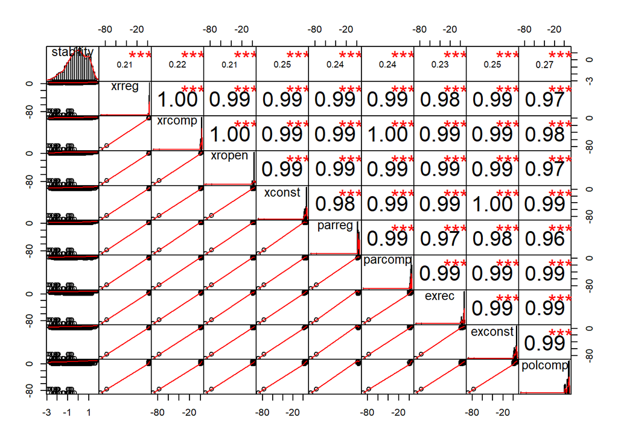

```r
# Correlation between Political Stability and the other Polity IV indicators

polityIvIndicators2 <- select(WGIdevRegimeType, stability, xrreg, xrcomp, xropen, xconst, parreg, parcomp, exrec, exconst, polcomp)
correlationPolityIv2 <- chart.Correlation(polityIvIndicators2)
```

```r
correlationPolityIv2
```

```r
# Correlation matrix with significance levels
correlationPolityIv2 <- rcorr(as.matrix(polityIvIndicators2))
correlationPolityIv2
```

```
##           stability xrreg xrcomp xropen xconst parreg parcomp exrec
## stability      1.00  0.21   0.22   0.21   0.25   0.24    0.24  0.23
## xrreg          0.21  1.00   1.00   0.99   0.99   0.99    0.99  0.98
## xrcomp         0.22  1.00   1.00   1.00   0.99   0.99    1.00  0.99
## xropen         0.21  0.99   1.00   1.00   0.99   0.99    0.99  0.99
## xconst         0.25  0.99   0.99   0.99   1.00   0.98    0.99  0.99
## parreg         0.24  0.99   0.99   0.99   0.98   1.00    0.99  0.97
## parcomp        0.24  0.99   1.00   0.99   0.99   0.99    1.00  0.99
## exrec          0.23  0.98   0.99   0.99   0.99   0.97    0.99  1.00
## exconst        0.25  0.99   0.99   0.99   1.00   0.98    0.99  0.99
## polcomp        0.27  0.97   0.98   0.97   0.99   0.96    0.99  0.99
##           exconst polcomp
## stability    0.25    0.27
## xrreg        0.99    0.97
## xrcomp       0.99    0.98
## xropen       0.99    0.97
## xconst       1.00    0.99
## parreg       0.98    0.96
## parcomp      0.99    0.99
## exrec        0.99    0.99
## exconst      1.00    0.99
## polcomp      0.99    1.00
##
## n= 2345
##
##
## P
##           stability xrreg xrcomp xropen xconst parreg parcomp exrec
## stability            0     0      0      0      0      0       0
## xrreg      0               0      0      0      0      0       0
## xrcomp     0         0            0      0      0      0       0
## xropen     0         0     0             0      0      0       0
## xconst     0         0     0      0             0      0       0
## parreg     0         0     0      0      0             0       0
## parcomp    0         0     0      0      0      0              0
## exrec      0         0     0      0      0      0      0
## exconst    0         0     0      0      0      0      0       0
## polcomp    0         0     0      0      0      0      0       0
##           exconst polcomp
## stability  0       0
## xrreg      0       0
## xrcomp     0       0
## xropen     0       0
## xconst     0       0
## parreg     0       0
## parcomp    0       0
## exrec      0       0
## exconst            0
## polcomp    0
```

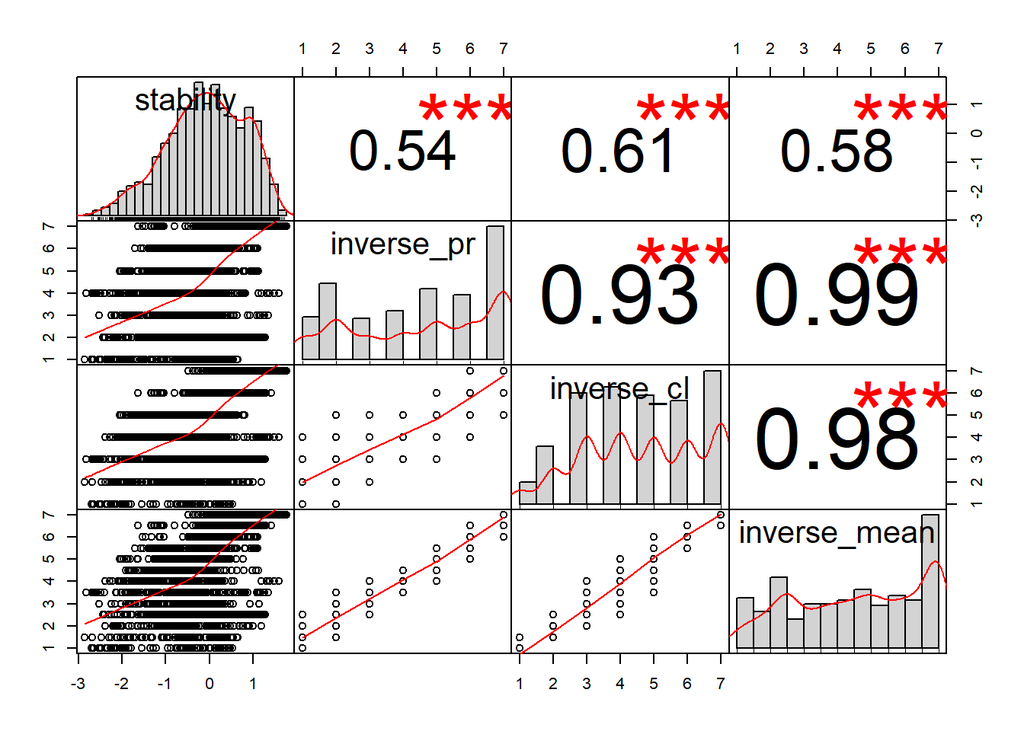

```r
# Correlation between Political Stability and Freedom House indicators

freedomHouseIndicators <- select(WGIdevRegimeType, stability, inverse_pr, inverse_cl, inverse_mean)
correlationFreedomHouse <- chart.Correlation(freedomHouseIndicators)
```

```r
correlationFreedomHouse
```

```r
# Correlation matrix with significance levels
correlationFreedomHouse <- rcorr(as.matrix(freedomHouseIndicators))
correlationFreedomHouse
```

```
##              stability inverse_pr inverse_cl inverse_mean
## stability         1.00       0.54       0.61         0.58
## inverse_pr        0.54       1.00       0.93         0.99
## inverse_cl        0.61       0.93       1.00         0.98
## inverse_mean      0.58       0.99       0.98         1.00
##
## n= 2345
##
##
## P
##              stability inverse_pr inverse_cl inverse_mean
## stability               0          0          0
## inverse_pr    0                    0          0
## inverse_cl    0         0                     0
## inverse_mean  0         0          0
```

In addition to the correlation chart, we can also cross-tabulate political stability and the categorical variables, such as

- devCategory
- polityCategory
- politicalChange
- status
- politicalChangeFH

```r
#Crosstabulation between stability category and development category

#using World Bank data on GNI per capita and development category

stabilityAndDevCategory <- table(WGIdevRegimeType$devCategory, WGIdevRegimeType$stabilityCategory)
prop.table(stabilityAndDevCategory, 1)
```

```
##
##                       Highly Stable Highly Unstable Moderately Stable
##   High Income           0.383333333     0.037878788       0.510606061
##   Low Income            0.002057613     0.395061728       0.170781893
##   Lower Middle Income   0.009404389     0.214733542       0.183385580
##   Upper Middle Income   0.048128342     0.121212121       0.488413547
##
##                       Moderately Unstable
##   High Income                 0.068181818
##   Low Income                  0.432098765
##   Lower Middle Income         0.592476489
##   Upper Middle Income         0.342245989
```

```r
#test of independence
chisq.test(stabilityAndDevCategory)
```

```
##
##  Pearson's Chi-squared test
##
## data:  stabilityAndDevCategory
## X-squared = 1172.1, df = 9, p-value < 2.2e-16
```

```r
#Crosstabulation between stability category and polity category / status
#using polity IV data
stabilityAndPolityCat <- table(WGIdevRegimeType$polityCategory, WGIdevRegimeType$stabilityCategory)
prop.table(stabilityAndPolityCat, 1)
```

```
##
##             Highly Stable Highly Unstable Moderately Stable
##   Anocracy     0.02911392      0.37088608        0.15316456
##   Autocracy    0.04290429      0.13531353        0.43894389
##   Democracy    0.20047923      0.07028754        0.44488818
##
##             Moderately Unstable
##   Anocracy           0.44683544
##   Autocracy          0.38283828
##   Democracy          0.28434505
```

```r
#test of independence
chisq.test(stabilityAndPolityCat)
```

```
##
##  Pearson's Chi-squared test
##
## data:  stabilityAndPolityCat
## X-squared = 546.46, df = 6, p-value < 2.2e-16
```

```r
#using Freedom House data
stabilityAndPolityCatFH <- table(WGIdevRegimeType$status, WGIdevRegimeType$stabilityCategory)
prop.table(stabilityAndPolityCatFH, 1)
```

```
##
##               Highly Stable Highly Unstable Moderately Stable
##   Free           0.25583756      0.03654822        0.53807107
##   Not Free       0.02692998      0.30520646        0.26750449
##   Partly Free    0.02490660      0.26899128        0.16438356
##
##               Moderately Unstable
##   Free                 0.16954315
##   Not Free             0.40035907
##   Partly Free          0.54171856
```

```r
#test of independence
chisq.test(stabilityAndPolityCatFH)
```

```
##
##  Pearson's Chi-squared test
##
## data:  stabilityAndPolityCatFH
## X-squared = 814.28, df = 6, p-value < 2.2e-16
```

```r
#Crosstabulation between political change and polity category / status
#using polity IV data
changeAndPolityCat <- table(WGIdevRegimeType$polityCategory, WGIdevRegimeType$politicalChange)
prop.table(changeAndPolityCat, 1)
```

```
##
##             autocratization democratization   no change
##   Anocracy      0.049367089     0.107594937 0.843037975
##   Autocracy     0.026402640     0.013201320 0.960396040
##   Democracy     0.007188498     0.029552716 0.963258786
```

```r
#test of independence
chisq.test(changeAndPolityCat)
```

```
##
##  Pearson's Chi-squared test
##
## data:  changeAndPolityCat
## X-squared = 109.85, df = 4, p-value < 2.2e-16
```

```r
#using Freedom House data
changeAndStatus <- table(WGIdevRegimeType$status, WGIdevRegimeType$politicalChangeFH)
prop.table(changeAndStatus, 1)
```

```
##
##               autocratization democratization  no change
##   Free             0.02741117      0.05482234 0.91776650
##   Not Free         0.08976661      0.04847397 0.86175943
##   Partly Free      0.11207970      0.13698630 0.75093400
```

```r
#test of independence
chisq.test(changeAndStatus)
```

```
##
##  Pearson's Chi-squared test
##
## data:  changeAndStatus
## X-squared = 109.19, df = 4, p-value < 2.2e-16
```